# Trabajo Práctico Final

Enfoque Estadístico del Aprendizaje - Año 2022

Alfredo Lopez - Verónica Agüero

```r
# Librerias utilizadas
library(dplyr)
library(tidyverse)
library(ggplot2)
library(ggthemes)  # estilos de gráficos
library(ggrepel)   # etiquetas de texto más prolijas que las de ggplot
library(GGally)
library(knitr)
library(reshape)
library(tidyr)
library(mvnormtest)
library(MASS)
library(biotools)
library(MVN)
library(reshape2)
library(gridExtra)
```

# 1. Objetivo

Aplicar los métodos de clasificación supervisada de Análisis Discriminante Lineal y Cuadrático para elaborar modelos que permitan clasificar si una muestra de agua es apta para el consumo humano o no.

# 2. Datos

El dataset utilizado en el presente trabajo contiene 9 métricas de la calidad del agua para 3276 muestras diferentes, las diferentes métricas son: ph, Hardness, Solids, Chloramines, Sulfate, Conductivity, Organic_carbon, Trihalomethanes y Turbidity. A partir de dichas variables se tiene finalmente la variable Potability que indica si el agua es no potable (valor 0) o potable (valor 1).

Fuente: https://www.kaggle.com/datasets/adityakadiwal/water-potability

# 3. Análisis Exploratorio y Preprocesamiento

**Lectura del dataset**

```r
dfwater = read.csv(file='Datasets/water_potability.csv', encoding = "UTF-8")
```

**Verificación del tamaño del dataset**

```r
dfwater %>% dim_desc()
```

```
[1] "[3,276 x 10]"
```

**Visualización de estructura y variables**

```r
head(dfwater)
```

|  | ph | Hardness | Solids | Chloramines | Sulfate | Conductivity | Organic_carbon | Trihalomethanes | Turbidity | Potability |
| --- | --- | --- | --- | --- | --- | --- | --- | --- | --- | --- |
| 1 | NA | 204.8905 | 20791.32 | 7.300212 | 368.5164 | 564.3087 | 10.379783 | 86.99097 | 2.963135 | 0 |
| 2 | 3.716080 | 129.4229 | 18630.06 | 6.635246 | NA | 592.8854 | 15.180013 | 56.32908 | 4.500656 | 0 |
| 3 | 8.099124 | 224.2363 | 19909.54 | 9.275884 | NA | 418.6062 | 16.868637 | 66.42009 | 3.055934 | 0 |
| 4 | 8.316766 | 214.3734 | 22018.42 | 8.059332 | 356.8861 | 363.2665 | 18.436524 | 100.34167 | 4.628771 | 0 |
| 5 | 9.092223 | 181.1015 | 17978.99 | 6.546600 | 310.1357 | 398.4108 | 11.558279 | 31.99799 | 4.075075 | 0 |
| 6 | 5.584087 | 188.3133 | 28748.69 | 7.544869 | 326.6784 | 280.4679 | 8.399735 | 54.91786 | 2.559708 | 0 |

```r
summary(dfwater)
```

```
       ph            Hardness          Solids         Chloramines        Sulfate       Conductivity   Organic_carbon  Trihalomethanes     Turbidity       Potability
 Min.   : 0.000   Min.   : 47.43   Min.   :  320.9   Min.   : 0.352   Min.   :129.0   Min.   :181.5   Min.   : 2.20   Min.   :  0.738   Min.   :1.450   Min.   :0.0000
 1st Qu.: 6.093   1st Qu.:176.85   1st Qu.:15666.7   1st Qu.: 6.127   1st Qu.:307.7   1st Qu.:365.7   1st Qu.:12.07   1st Qu.: 55.845   1st Qu.:3.440   1st Qu.:0.0000
 Median : 7.037   Median :196.97   Median :20927.8   Median : 7.130   Median :333.1   Median :421.9   Median :14.22   Median : 66.622   Median :3.955   Median :0.0000
 Mean   : 7.081   Mean   :196.37   Mean   :22014.1   Mean   : 7.122   Mean   :333.8   Mean   :426.2   Mean   :14.28   Mean   : 66.396   Mean   :3.967   Mean   :0.3901
 3rd Qu.: 8.062   3rd Qu.:216.67   3rd Qu.:27332.8   3rd Qu.: 8.115   3rd Qu.:360.0   3rd Qu.:481.8   3rd Qu.:16.56   3rd Qu.: 77.337   3rd Qu.:4.500   3rd Qu.:1.0000
 Max.   :14.000   Max.   :323.12   Max.   :61227.2   Max.   :13.127   Max.   :481.0   Max.   :753.3   Max.   :28.30   Max.   :124.000   Max.   :6.739   Max.   :1.0000
 NA's   :491                                                          NA's   :781                                     NA's   :162
```

Se observa que las variables ph, Sulfate y Trihalomethanes presentan valores perdidos, por ende a continuación se pone énfasis en los mismos para observar con claridad la cantidad y el porcentaje que representan.

```r
# Verificación de valores faltantes

tabla_faltantes = dfwater %>%
                              gather(.,
                                     key = "variables",
                                     value = "valores") %>%
                              group_by(variables) %>%
                              summarise(
                                cant_faltantes = sum(is.na(valores)),
                                porcentaje_faltantes = sum(is.na(valores))/nrow(dfwater)*100
                              )

tabla_faltantes
```

| variables | cant_faltantes | porcentaje_faltantes |
| --- | --- | --- |
| Chloramines | 0 | 0.000000 |
| Conductivity | 0 | 0.000000 |
| Hardness | 0 | 0.000000 |
| Organic_carbon | 0 | 0.000000 |
| ph | 491 | 14.987790 |
| Potability | 0 | 0.000000 |
| Solids | 0 | 0.000000 |
| Sulfate | 781 | 23.840049 |
| Trihalomethanes | 162 | 4.945055 |
| Turbidity | 0 | 0.000000 |

A partir de la cantidad y porcentaje de valores faltantes encontrados, con el fin de que los mismos no influyan en los modelos se decidió quitar las filas con valores perdidos.

```r
# Eliminación de filas con datos faltantes

dfwater <- dfwater %>% drop_na(ph) %>% drop_na(Sulfate) %>% drop_na(Trihalomethanes)

# Verificación del nuevo tamaño del dataset
dfwater %>% dim_desc()
```

```
[1] "[2,011 x 10]"
```

A continuación, se verifica la cantidad de observaciones según la clasificación de las muestras (Potable, No potable)

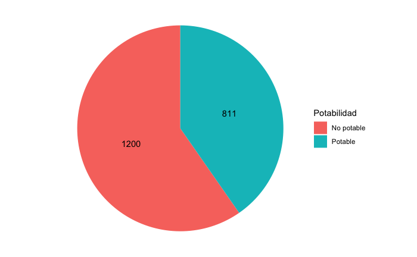

```r
datos_grafico_torta <- dfwater %>%
                        group_by(Potability) %>%
                        count() %>%
                        mutate(Potabilidad = case_when(Potability == 0 ~ "No potable",
                                                           Potability == 1 ~ "Potable"))

ggplot(datos_grafico_torta, aes(x = "", y = n, fill = Potabilidad)) +
  geom_col() +
  geom_text(aes(label = n),
            position = position_stack(vjust = 0.5)) +
  coord_polar(theta = "y") +
  theme_void()
```

## Análisis de correlación

Para ver el comportamiento de las variables en función de la variable de clasificación Potability en sus diferentes valores, vamos a analizar la correlación de las variables.

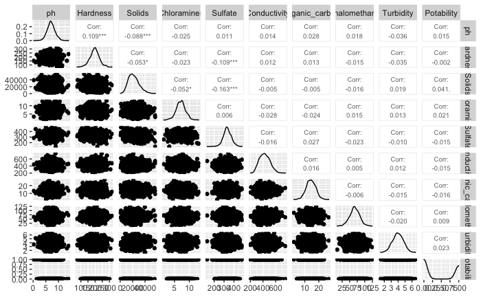

```r
ggpairs(data = dfwater, upper = list(continuous = wrap("cor", size = 2.5, hjust=0.5)), progress=FALSE)
```

Se observa que todas las variables presentan una correlación demasiado debil con la variable de clasificación Potability. Si analizamos en detalle, podemos observar que las variables ph, Solids, Chloramines, Trihalomethanes y Turbidity tiene una BAJA correlación POSITIVA mientras que Hardness, Sulfate, Conductivity y Organic_carbon tinen una BAJA correlación NEGATIVA con la variable de clasificación Potability.

Para analizar el comportamiento de las variables realizaremos una serie de gráficos para más detalle

## Box Plot por variable

Con el Box-plot por variable vamos a poder observar el comportamiento de cada una de las variables en función de los valores que puede tomar la variable de clasificación.

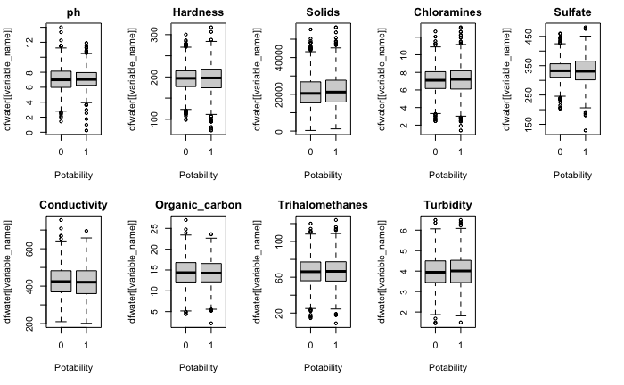

```r
par(mfrow=c(2,5))
for (k in 1:9) {
  variable_name <- names(dfwater)[k]
  boxplot(dfwater[[variable_name]] ~ Potability, data = dfwater, main = variable_name)
}
```

De este gráfico podemos observar que las variables en cada una de las clases tienen una media con un valor similar. **Importante tener en cuenta esto porque lo vamos a desarrollar más adelante cuando apliquemos el método.**

## Distribución en Histograma por variables

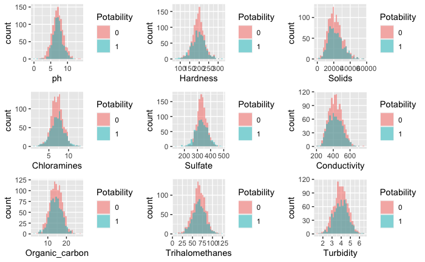

```r
# Representación de distribución en histogramas
p1 <- ggplot(data = dfwater, aes(x = ph)) +
geom_histogram(position = "identity", alpha = 0.5, aes(fill = as.factor(Potability)))+labs(fill = "Potability")
p2 <- ggplot(data = dfwater, aes(x = Hardness)) +
geom_histogram(position = "identity", alpha = 0.5, aes(fill = as.factor(Potability)))+labs(fill = "Potability")
p3 <- ggplot(data = dfwater, aes(x = Solids)) +
geom_histogram(position = "identity", alpha = 0.5, aes(fill = as.factor(Potability)))+labs(fill = "Potability")
p4 <- ggplot(data = dfwater, aes(x = Chloramines)) +
geom_histogram(position = "identity", alpha = 0.5, aes(fill = as.factor(Potability)))+labs(fill = "Potability")
p5 <- ggplot(data = dfwater, aes(x = Sulfate)) +
geom_histogram(position = "identity", alpha = 0.5, aes(fill = as.factor(Potability)))+labs(fill = "Potability")
p6 <- ggplot(data = dfwater, aes(x = Conductivity)) +
geom_histogram(position = "identity", alpha = 0.5, aes(fill = as.factor(Potability)))+labs(fill = "Potability")
p7 <- ggplot(data = dfwater, aes(x = Organic_carbon)) +
geom_histogram(position = "identity", alpha = 0.5, aes(fill = as.factor(Potability)))+labs(fill = "Potability")
p8 <- ggplot(data = dfwater, aes(x = Trihalomethanes)) +
geom_histogram(position = "identity", alpha = 0.5, aes(fill = as.factor(Potability)))+labs(fill = "Potability")
p9 <- ggplot(data = dfwater, aes(x = Turbidity)) +
geom_histogram(position = "identity", alpha = 0.5, aes(fill = as.factor(Potability)))+labs(fill = "Potability")

grid.arrange(p1, p2, p3, p4, p5, p6, p7, p8, p9)
```

## Normalización

Debido a la diferente escala que maneja cada una de las variables, se decide normalizarlas para aplicar la técnica.

```r
#View(dfwater)
# Funcion Normalizacion Min-Max
fn_normalizacion <- function (x) {
  (x - min(x)) / (max(x) - min(x))
}

# Agregacion de las variables normalizadas
dfwater_norm <- dfwater %>%
              mutate(ph_norm = fn_normalizacion(ph),
                     Hardness_norm = fn_normalizacion(Hardness),
                     Solids_norm = fn_normalizacion(Solids),
                     Chloramines_norm = fn_normalizacion(Chloramines),
                     Sulfate_norm = fn_normalizacion(Sulfate),
                     Conductivity_norm = fn_normalizacion(Conductivity),
                     Organic_carbon_norm = fn_normalizacion(Organic_carbon),
                     Trihalomethanes_norm = fn_normalizacion(Trihalomethanes),
                     Turbidity_norm = fn_normalizacion(Turbidity)
                     )

# Obtencion de las variables normalizadas
dfwater <- dfwater_norm %>%
              dplyr::select(ph_norm,Hardness_norm,Solids_norm,Chloramines_norm,Sulfate_norm,Conductivity_norm,
                            Organic_carbon_norm,Trihalomethanes_norm,Turbidity_norm,Potability)

# Renombramiento de las variables
dfwater <- dfwater %>%
              dplyr::rename(ph = ph_norm,
                     Hardness  = Hardness_norm,
                     Solids = Solids_norm,
                     Chloramines = Chloramines_norm,
                     Sulfate = Sulfate_norm,
                     Conductivity = Conductivity_norm,
                     Organic_carbon = Organic_carbon_norm,
                     Trihalomethanes = Trihalomethanes_norm,
                     Turbidity = Turbidity_norm
                      )
```

# 4. Cumplimiento de Supuestos

## 4.1 Análisis de Normalidad

Para nuestro caso tenemos $k = 2$ tendríamos 2 clases, entonces se define:

Para K=1 $f_1(x) = P(Y = 0|X = x) = \frac{1}{\sqrt{2\pi\sigma_1}}exp(\frac{-1}{2\sigma_1^2}(x - \mu_1)^2)$

Para k=2 $f_2(x) = P(Y = 0|X = x) = \frac{1}{\sqrt{2\pi\sigma_2}}exp(\frac{-1}{2\sigma_2^2}(x - \mu_2)^2)$

Uno de los supuestos para la aplicación del método de Análisis Discriminante Lineal, es el supuesto de normalidad, vamos a iniciar el análisis revisando en principio la normalidad univariante.

### 4.1.1 Normalidad Univariante

Consiste en representar los datos mediante un histograma y superponer la curva de una distribución ormal con la misma media y desviación estándar que muestran los datos.

Al realizar el análisis de la normalidad, puede suceder que si se observa que los datos tienen una distribución normal multivariante, entonces cada una de las variables tiene una disrtibución normal univariante.

**Histograma por variable**

Para *Potability = 0*:

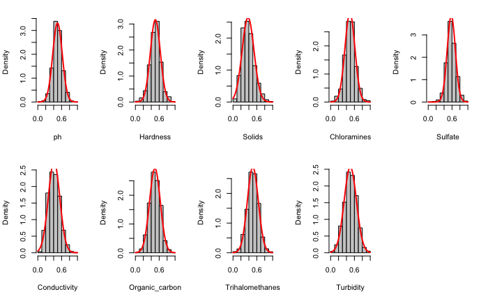

```r
par(mfrow= c(2,5))

for (k in 1:9) {
  variable_name <- names(dfwater)[k]
  x <- dfwater[dfwater$Potability == 0, variable_name ]
  hist(dfwater[[variable_name]], proba = T, col = grey(0.8), main = "", xlab=variable_name)
  x0 <- seq(min(dfwater[, k]), max(dfwater[, k]), le = 50)
  lines(x0, dnorm(x0, mean(x), sd(x)), col = "red", lwd = 2)
}
```

Para *Potability = 1*:

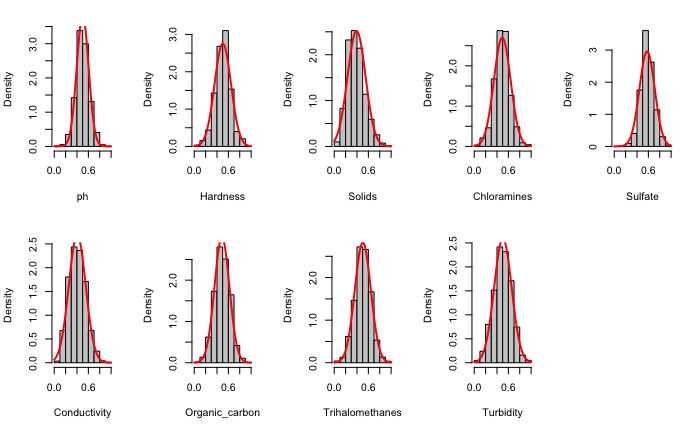

```r
par(mfrow= c(2,5))

for (k in 1:9) {
  variable_name <- names(dfwater)[k]
  x <- dfwater[dfwater$Potability == 1, variable_name ]
  hist(dfwater[[variable_name]], proba = T, col = grey(0.8), main = "", xlab=variable_name)
  x0 <- seq(min(dfwater[, k]), max(dfwater[, k]), le = 50)
  lines(x0, dnorm(x0, mean(x), sd(x)), col = "red", lwd = 2)
}
```

**QQ-Plot por variable**

Para *Potability = 0*:

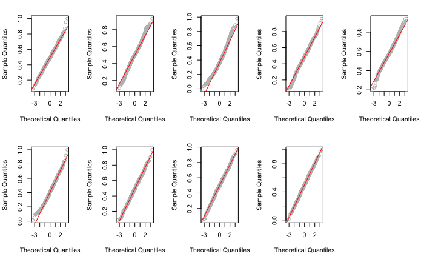

```r
par(mfrow= c(2,5))

for (k in 1:9) {
  variable_name <- names(dfwater)[k]
  x <- dfwater[dfwater$Potability == 0, variable_name ]
  qqnorm(dfwater[Potability == 0, k],
       col = "grey",
       main = "")
  qqline(dfwater[Potability  == 0, k], col = "red")
}
```

Para *Potability = 1*:

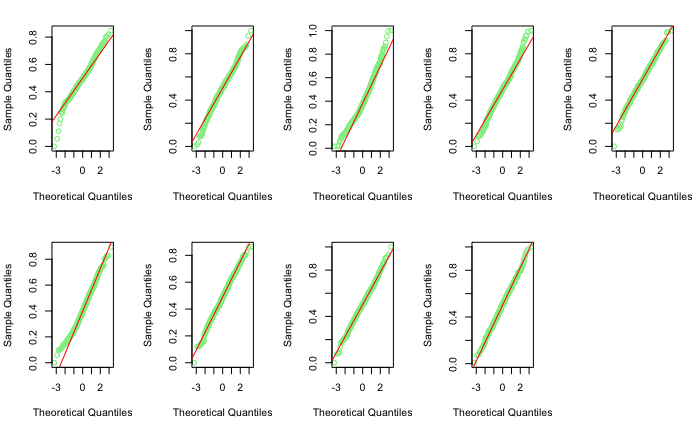

```r
par(mfrow= c(2,5))

for (k in 1:9) {
  variable_name <- names(dfwater)[k]
  x <- dfwater[dfwater$Potability == 1, variable_name ]
  qqnorm(dfwater[Potability == 1, k],
       col = "lightgreen",
       main = "")
  qqline(dfwater[Potability  == 1, k], col = "red")
}
```

Para testear la Normalidad Univariante utilizaremos el test de **Shapiro-Wilks** sobre cada variable predictora.

El test de Shapiro-Wilks plantea como hipótesis nula que los datos de la muestra provienen de una Distribución Normal.

Se define:

$H_0: X \backsim N(\mu,\sigma^2)$ Los datos se distribuyen normal.

$H_1: X \nsim N(\mu,\sigma^2)$ Los datos no se distribuyen normal.

Con este test se busca rechazar la hipótesis nula para $\alpha = 0.05$.

Definición de la variable objetivo Potability como factor

```r
dfwater$Potability = as.factor(dfwater$Potability)
```

Aplicamos el test de Shapiro Wilks por cada variable, en función de los diferentes valores que puede tomar la clase.

```r
# Contraste de normalidad Shapiro-Wilk para cada variable en cada rendimiento
dfwater.tidy <- melt(dfwater, value.name = "valor")
dfwater.tidy %>% group_by(Potability, variable) %>% summarise(p_value_Shapiro.test = shapiro.test(valor)$p.value) %>% mutate_if(is.numeric, round, digits = 10)
```

| Potability | variable | p_value_Shapiro.test |
| --- | --- | --- |
| 0 | ph | 0.2032006187 |
| 0 | Hardness | 0.0014141180 |
| 0 | Solids | 0.0000000000 |
| 0 | Chloramines | 0.0158441418 |
| 0 | Sulfate | 0.0005174605 |
| 0 | Conductivity | 0.0000346489 |
| 0 | Organic_carbon | 0.7364787696 |
| 0 | Trihalomethanes | 0.2237308748 |
| 0 | Turbidity | 0.8989376541 |
| 1 | ph | 0.0000044133 |

[output cut: 8 more lines]

### 4.1.2 Normalidad Multivariante

Además de testear la normalidad univariante, se requiere evaluar la normalidad multivariante. Antes de aplicar algún test se analizará la presencia de valores atípicos, ya que los outliers pueden ser causa de no cumplir esta condición. Es conveniente verificar si los datos tienen outliers multivariantes (valores extremos para combinaciones de variables) antes de comenzar con el análisis multivariante.

El *multivariateOutlierMethod* emple el método de cuantiles basado en la distancia de Mahalanobis y la distancia de Mahalanobis ajustada.

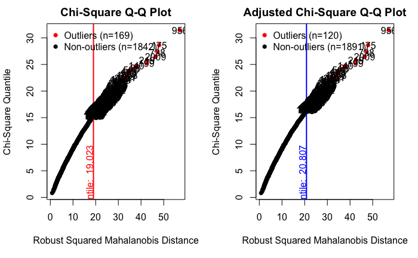

```r
par(mfrow = c(1, 2))
# Distancia de Mahalanobis
outliers <- mvn(data = dfwater[,-10], multivariateOutlierMethod = "quan")
# Distancia ajustada de Mahalanobis
outliers.adj <- mvn(data = dfwater[,-10], multivariateOutlierMethod = "adj")
```

De este análisis podemos observar que tenemos una proporción de moderada a baja de presencia de outliers en las clases, se observa alrededor del 5 y 8.5% de outliers.

**Test MVN de Royston**

El test de Royston se basa en el test de *Shapiro-Wilk*. Utilizamos la libraría MVN. en este caso no es posible aplicar la técnica ya que el número de observaciones (2011) supera la cantidad permitida por este test en la librería usada (2000)

```r
royston <- mvn(data = dfwater[,-10], mvnTest = "royston", multivariatePlot = "qq")
```

```
Error in royston(data, tol = tol) : n must be less than 2000
```

**Test MVN de Mardia**

El test de Mardia calcula los coeficientes de asimetría y curtosis y la corresponiente significancia estadística, combinando ambos para dar un resultado global de normalidad multivariante (MVN):

```r
mardia <- mvn(data = dfwater[,-10], mvnTest = "mardia")
mardia$multivariateNormality
```

| Test | Statistic | p value | Result |
| --- | --- | --- | --- |
| Mardia Skewness | 419.938826127048 | 3.62218428752613e-24 | NO |
| Mardia Kurtosis | 12.0870044545676 | 0 | NO |
| MVN | NA | NA | NO |

**Test MVN de Henze-Zirkler**

```r
henze.zirkler <- mvn(data = dfwater[,-10], mvnTest = "hz")
henze.zirkler$multivariateNormality
```

| Test | HZ | p value | MVN |
| --- | --- | --- | --- |
| Henze-Zirkler | 1.151143 | 0 | NO |

**NOTA**: Se pudo aplicar 2 de los 3 test propuestos y muestran evidencias significativas con $\alpha = 0.05$ de que los datos no siguen una Distribución Normal Multivaraiante, esto puede ocurrir porque hay falta de normalidad univariante en varias variables como mencionamos anteriormente (Ver Apartado 4.1.1). Esto va a afectar a la precisión de las técnicas que se desarrollarán en este trabajo.

## 4.2 Análisis de igualdad de matrices de varianzas y covarianzas

El test M de Box se utiliza para determinar la homogeneidad de las matrices de covarianza obtenidas a partir de datos normales multivariados según uno o más factores de clasificación. Tiene como hipotesis nula que las matrices de covarianza son iguales. Es de la librería *biotools*.

**NOTA**: Este test es sensible a la falta de normalidad multivariante.

$H_0: Las\ matrices\ de\ covarianza\ son\ iguales$

$H_1: Las\ matrices\ de\ covarianza\ no\ son\ iguales$

```r
boxM(data = dfwater[, 1:9], grouping = dfwater[,10])
```

```
    Box's M-test for Homogeneity of Covariance Matrices

data:  dfwater[, 1:9]
Chi-Sq (approx.) = 491.02, df = 45, p-value < 2.2e-16
```

Se observa que no se cumple la condición de matriz de covarianza común entre las dos clases.

Dado que no se cumplen las dos condiciones, a priori lo conveniente sería aplicar QDA en lugar de LDA. Sin embargo, igualmente se aplicará LDA a fines del análisis del presente trabajo para luego comparar los resultados obtenidos con la aplicación de QDA.

# 5. Cálculo de función discriminante

División del set de datos en entrenamiento (80%) y en test (20%)

```r
# Fijación de semilla

set.seed(500)

# Partición de los datos

dt <- sort(sample(nrow(dfwater), nrow(dfwater)*.8))
datos_train <- dfwater[dt,]
datos_test <- dfwater[-dt,]
```

Definición de fórmulas

Se analizaron diferentes alternativas y se decidió elegir aquellas variables que tienen mayor correlación.

```r
#formula_regresora <- formula(Potability ~ ph + Hardness + Solids + Chloramines + Sulfate + Conductivity + Organic_carbon + Trihalomethanes + Turbidity)
#formula_regresora <- formula(Potability ~ Solids + Chloramines + Turbidity)
formula_regresora <- formula(Potability ~ ph + Solids + Chloramines + Sulfate + Conductivity + Organic_carbon + Turbidity)
#formula_regresora <- formula(Potability ~ ph + Hardness + Solids + Chloramines + Sulfate + Conductivity)
```

## 5.1 Análisis discriminante líneal (LDA)

### 5.1.1. Marco Teórico

El Análisis Discriminante Lineal o Linear Discrimiant Analysis (LDA) es un método de clasificación supervisado de variables cuantitativas en el que dos o más grupos son conocidos a priori y nuevas observaciones se clasifican en uno de ellos en función de sus características. Haciendo uso del teorema de Bayes, LDA estima la probabilidad de que una observación, dado un determinado valor de los predictores, pertenezca a cada una de las clases de la variable cualitativa, P(Y=k|X=x). Finalmente se asigna la observación a la clase k para la que la probabilidad predicha es mayor.

En el contexto de la clasificación, mediante el teorema de Bayes se calcula la probabilidad de que la variable respuesta Y pertenezca a cada uno de los posibles niveles, dados unos determinados valores de los predictores.

Suponiendo que $\pi_k$ representa la *probabilidad a priori* de que una observación al azar provenga de la clase k de la variable respuesta Y, que se puede estimar como $\hat{\pi_k}=n_k/n$ y siendo $f_k(X)$ la función de densidad de probabilidad condicional de X para una observación que proviene de la clase k, el teorema de Bayes establece que:

$P(pertenecer\ a\ la\ clase\ k | valor\ x\ observado) = \frac{pertenecer\ a\ la\ clase\ k\ y\ observar\ x}{P(observar\ x)}$

Lo que en términos de probabilidades se puede traducir como:

$P(Y = k | X = x) = \frac{\pi_kP(X=x|Y=k)}{\sum_{j=0}^k\pi_jP(X=x|Y=j)} = \frac{\pi_kf_k(x)}{\sum_{j=0}^k\pi_jf_j(x)}$

donde $p_k(x)$ representa la *probabilidad a posteriori* de que una observación X = x pertenezcan a la clase k. **Cada observación se cladificará dentro del nivel que tiene la probabilidad $p_k(x) más alta**.

```r
modelo1=NULL

modelo1$lda <- lda(formula_regresora,datos_train)
modelo1$lda
```

```
Call:
lda(formula_regresora, data = datos_train)

Prior probabilities of groups:
        0         1
0.5982587 0.4017413

Group means:
         ph    Solids Chloramines   Sulfate Conductivity Organic_carbon Turbidity
0 0.4944777 0.3791961   0.4859976 0.5772979    0.4081068      0.4912033 0.4963897
1 0.4996722 0.3905467   0.4939579 0.5788040    0.4100697      0.4869092 0.5011609

Coefficients of linear discriminants:
                      LD1
ph              4.0985086
Solids          4.5030488
Chloramines     3.7964631
Sulfate         1.8614256
Conductivity    0.7800947
Organic_carbon -1.9862747
Turbidity       1.7280757
```

Las salidas del modelo calculado muestran:

- Probabilidad a-priori de los grupos: Proporción de las observaciones en cada grupo ($\pi_0$ = 0.598 y $\pi_1$ = 0.401).
- Group means: Media de cada variable en cada grupo y que luego son utilizadas como estimadores de $\mu_k$.
- Coefficients of linear discriminants: Muestra la combinación líneal de las variables predictoras utilizadas para definir la regla de decisión LDA, en este caso:

  LD = 4.09 x ph + 4.5 x Solids + 3.79 x Chloramines + 1.86 x Sulfate + 0.78 x Conductivity - 1.98 x Organic_carbon + 1.72 x Turbidity

**Visualización del Modelo**

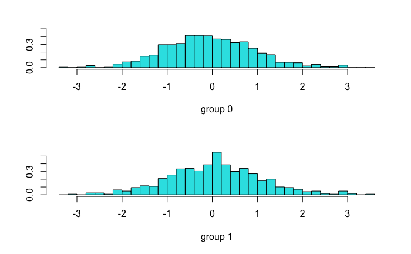

```r
plot(modelo1$lda)
```

## 5.2 Análisis discriminante cuadrático (QDA)

### 5.2.1. Marco Teórico

El clasificador cuadrático o Quadratic Discriminat Analysis QDA se asemeja en gran medida al LDA, con la única diferencia de que el QDA considera que cada clase k tiene su propia matriz de covarianza $(∑k)$ y, como consecuencia, la función discriminante toma forma cuadrática:

$log(P(Y=k|X=x)) = - \frac{1}{2}log|\sum_k| - \frac{1}{2}(x-\mu_k)^T\sum_k^{-1}(x - \mu_k) + log (\pi_k)$

Para poder calcular la probabilidad a posteriori a partir de esta ecuación discriminante es necesario estimar, para cada clase, $(∑k)$, $\mu_k$ y $\pi_k$ a partir de la muestra. Cada nueva observación se clasifica en aquella clase para la que el valor de la posterior probability sea mayor.

La ecuación no es una función lineal de x, sino cuadrática (de donde deriva el nombre del método “cuadrático”). Debido a esta propiedad, el QDA genera límites de decisión curvos, no lineales, por lo que es aplicable para casos en los que la separación entre grupos no es lineal.

### 5.2.2. Aplicación práctica

```r
modelo2=NULL

modelo2$qda <- qda(formula_regresora,datos_train)
modelo2$qda
```

```
Call:
qda(formula_regresora, data = datos_train)

Prior probabilities of groups:
        0         1
0.5982587 0.4017413

Group means:
         ph    Solids Chloramines   Sulfate Conductivity Organic_carbon Turbidity
0 0.4944777 0.3791961   0.4859976 0.5772979    0.4081068      0.4912033 0.4963897
1 0.4996722 0.3905467   0.4939579 0.5788040    0.4100697      0.4869092 0.5011609
```

Las salidas del modelo calculado muestran:

- Probabilidad a-priori de los grupos y medias de cada variable en cada grupo que en ambos casos coinciden con las salidas del modelo LDA.
- En este caso, no se muestran los coeficientes de la regla de decisión LDA ya que el clasificador QDA se basa en una función cuadrática de las variables predictoras.

# 6. Evaluación de los modelos

## 6.1 Evaluación LDA

Se evalua el modelo LDA en el dataset de test.

```r
lda.pred <-  predict(object = modelo1$lda, newdata = datos_test)
```

La función predict retorna:

- class: clase predicha de las observaciones
- Probabilidad a posteriori de que cada observación pertenezca a una clase determinada. La salida es una matriz donde las columnas son las clases, las filas son las diferentes observaciones y los valores son las probabilidades mencionadas.
- x: muestra los discriminantes lineales.

```r
# Predicciones de clase
head(lda.pred$class)
```

```
[1] 0 0 0 0 0 0
Levels: 0 1
```

```r
# Probabilidad a posteriori
head(lda.pred$posterior)
```

```
           0         1
3  0.5986114 0.4013886
4  0.5583102 0.4416898
6  0.5205184 0.4794816
10 0.5560393 0.4439607
15 0.5748102 0.4251898
16 0.6003720 0.3996280
```

```r
# Discriminante lineal
head(lda.pred$x)
```

```
             LD1
3   0.0002969066
4   1.3368630540
6   2.5668383998
10  1.4112495764
15  0.7937727630
16 -0.0589666060
```

A continuación, se genera la matriz de confusión del modelo LDA y se calcula el porcentaje de errores del modelo.

```r
# Matriz de confusion del modelo LDA
table(lda.pred$class, datos_test$Potability, dnn = c("Clase predicha", "Clase real"))
```

```
              Clase real
Clase predicha   0   1
             0 238 164
             1   0   1
```

Nótese que en este caso al aplicar el método podemos observar que la mayoría de las observaciones se clasifican como Potability = 0. No puede clasificar correctamente las clases.

```r
# Test error rate del modelo LDA
mean(lda.pred$class != datos_test$Potability)
```

```
[1] 0.4069479
```

Se tiene que el porcentaje de errores del modelo LDA es del 40%.

## 6.2 Evaluación QDA

```r
qda.pred <-  predict(object = modelo2$qda, newdata = datos_test)
```

La función predict para el caso de QDA retorna:

- class: clase predicha de las observaciones
- Probabilidad a posteriori de que cada observación pertenezca a una clase determinada. Al igual que para LDA, la salida es una matriz donde las columnas son las clases, las filas son las diferentes observaciones y los valores son las probabilidades mencionadas.

```r
# Predicciones de clase
head(qda.pred$class)
```

```
[1] 0 0 0 0 0 0
Levels: 0 1
```

```r
# Probabilidad a posteriori
head(qda.pred$posterior)
```

```
           0         1
3  0.7709347 0.2290653
4  0.8890857 0.1109143
6  0.8230070 0.1769930
10 0.8149127 0.1850873
15 0.8940006 0.1059994
16 0.6123771 0.3876229
```

A continuación, se genera la matriz de confusión del modelo QDA y se calcula el porcentaje de errores del modelo.

```r
# Matriz de confusion del modelo QDA
table(qda.pred$class, datos_test$Potability, dnn = c("Clase predicha", "Clase real"))
```

```
              Clase real
Clase predicha   0   1
             0 204  90
             1  34  75
```

En este caso vemos mayor separación de las clases aunque sigue persistiendo la alta tasa de error.

```r
# Test error rate del modelo QDA
mean(qda.pred$class != datos_test$Potability)
```

```
[1] 0.3076923
```

Se tiene que el porcentaje de errores del modelo QDA es del 30%.

# 7. Conclusiones

LDA es un método mucho menos flexible que QDA y se puede observar alta tasa de errores. El cumplimiento de los supuestos es un punto muy importante ya que de las pruebas realizadas podemos observar que la sensibilidad que presentan algunos tests se ve altamente afectada, obteniendo resultados poco satisfactorios.

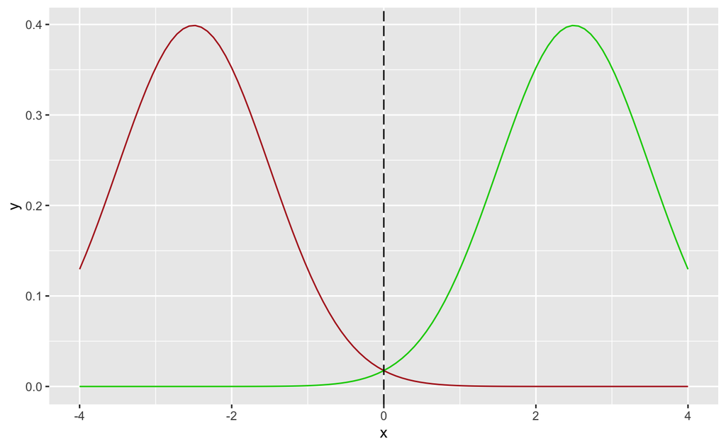

```r
library(ggplot2)
ggplot(data.frame(x = c(-4, 4)), aes(x)) +
stat_function(fun = dnorm, args = list(mean = -2.5, sd = 1),
              color = "firebrick") +
stat_function(fun = dnorm, args = list(mean = 2.5, sd = 1), color = "green3") +
geom_vline(xintercept = 0, linetype = "longdash")
```

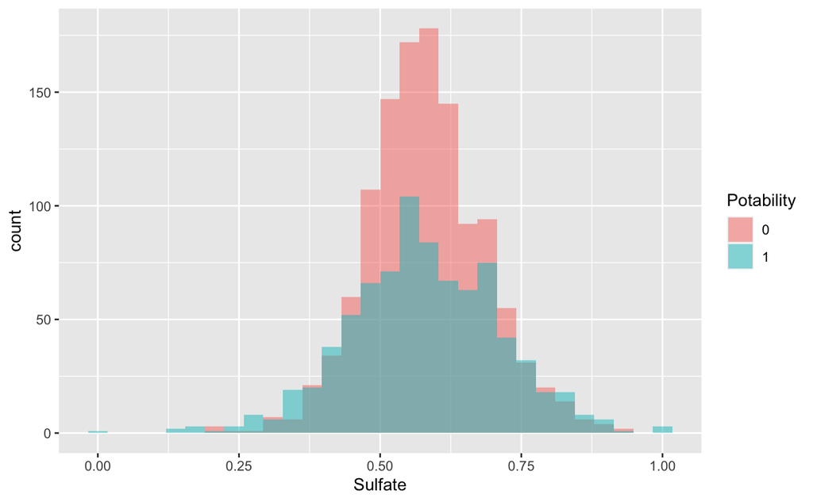

```r
p <- ggplot(data = dfwater, aes(x = Sulfate)) +
geom_histogram(position = "identity", alpha = 0.5, aes(fill = as.factor(Potability)))+labs(fill = "Potability")
p
```

# Bibliografía

1. An Introduction to Statistical Learning: with Applications in R (Springer Texts in Statistics)
2. Análisis Discriminante Lineal Y Cuadrático - Cristina Gil Martínez: https://github.com/CristinaGil/Estadistica_machine_learning_R
3. Análisis discriminante lineal (LDA) y análisis discriminante cuadrático (QDA) - Joaquín Amat Rodrigo: https://www.cienciadedatos.net/documentos/28_linear_discriminant_analysis_lda_y_quadratic_discriminant_analysis_qda#Ejemplo_QDA_con_2_predictores